# How Economy and Healthcare Impact Child Welfare

Author

Shivi Joshi

```
Saving unicef_metadata.csv to unicef_metadata.csv
```

## Military Spending vs Social Development

This bar chart highlights the top 10 countries with the highest military expenditure as a percentage of GDP.

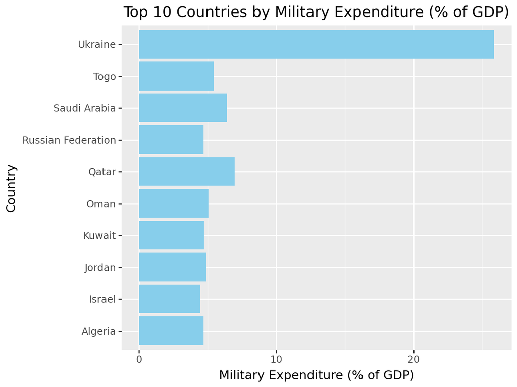

## Explanation

This bar chart highlights the top 10 countries with the highest military expenditure as a percentage of GDP in the most recent year available.

High military spending can indicate a nation’s focus on defense, but excessive allocation towards military budgets often comes at the cost of social sectors like healthcare, education, and child welfare.

This visualisation prompts reflection on how national priorities may divert resources away from critical services that directly impact human development.

## Life Expectancy Across Countries

The map below visualises global disparities in life expectancy.

[output not shown]

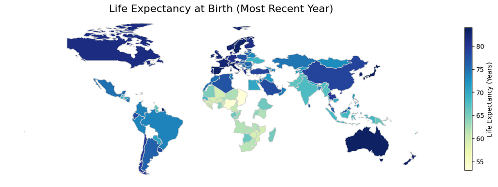

## Explanation

The world map above illustrates global variations in life expectancy at birth. Countries shaded in darker blue represent higher life expectancy, typically reflecting better healthcare systems, higher living standards, and greater social stability.

Lighter shades and blank areas indicate regions with lower life expectancy or missing data, often linked to challenges such as poor healthcare infrastructure, economic hardship, or conflict.

This visualisation emphasizes the ongoing disparities in global health outcomes.

## Healthcare Capacity vs Education Access

This scatterplot explores how healthcare infrastructure correlates with out-of-school rates.

```
Saving unicef_indicator_1.csv to unicef_indicator_1.csv
```

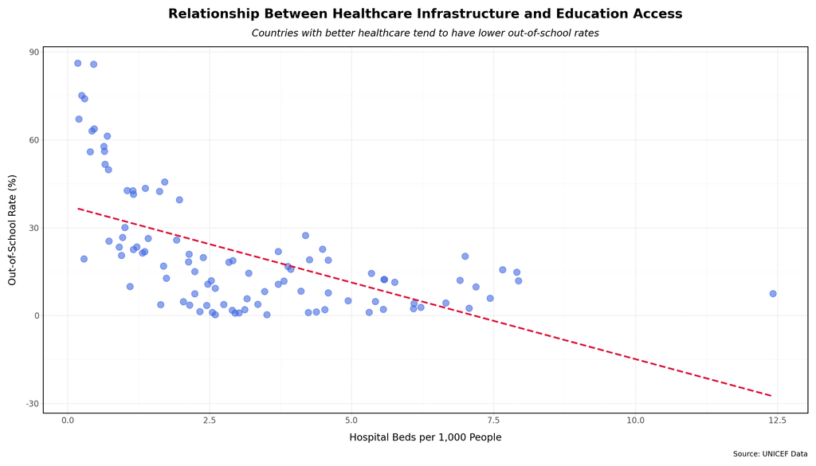

## Explanation

This scatterplot illustrates the relationship between a country’s healthcare infrastructure and its secondary education out-of-school rate.

A visible trend suggests that countries with more hospital beds per 1,000 people tend to have lower out-of-school rates. This indicates that stronger healthcare systems often correlate with better social development outcomes, including education.

Investments in public health can reflect broader commitments to human welfare, which positively influence children’s access to schooling.

## GDP Growth Trends (2000–2020)

This line chart illustrates the GDP per capita growth of five countries — India, Nigeria, Brazil, Germany, and Afghanistan — over two decades.

The visualisation highlights how long-term economic stability plays a crucial role in enabling governments to support social development, reduce poverty, and improve outcomes for future generations.

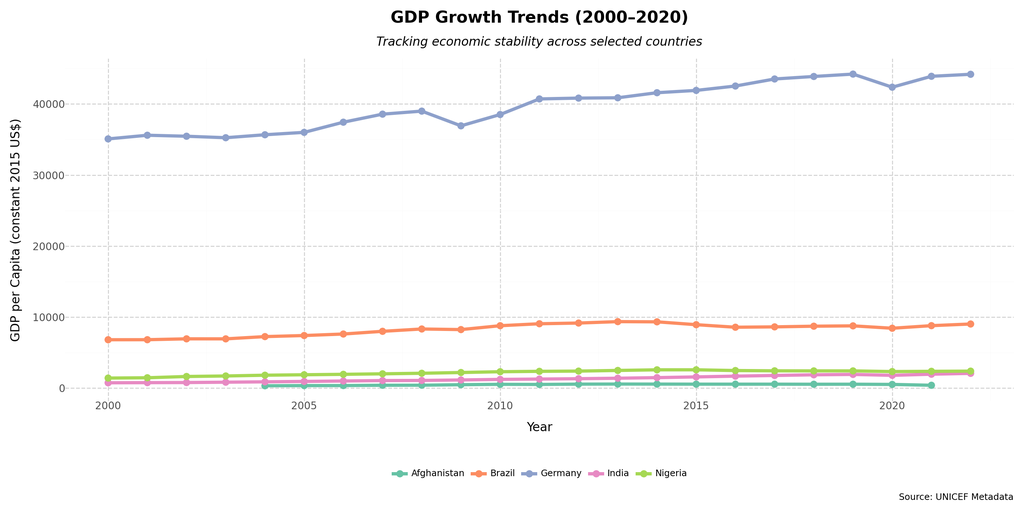

### Explanation

These trends are significant because consistent economic growth provides governments with the fiscal space to invest in essential public services. Without this stability, funding for healthcare, education, and child welfare becomes unpredictable, directly impacting human development indicators.

This chart reinforces the broader narrative that **sustainable economic policies** are foundational to improving children’s futures.

## Conclusion and Final Thoughts

This analysis highlights the deep interconnection between a country’s economic performance, its investment in healthcare, and the overall well-being of its younger population. Through the exploration of multiple indicators, it becomes evident that nations with stable economies and robust healthcare systems are better positioned to support child welfare, particularly in areas like education and health outcomes.

The visualisation of military expenditure revealed how excessive focus on defense spending can divert essential resources away from critical social sectors. Countries allocating a significant portion of their GDP to military budgets often face challenges in maintaining adequate investments in healthcare and education, which directly impacts children’s access to basic services.

The world map of life expectancy showcased stark contrasts between developed and developing regions. Higher life expectancy tends to correlate with countries that have prioritized public health infrastructure and economic stability. In contrast, regions with limited healthcare access and unstable economies continue to struggle with lower life expectancy rates, reflecting systemic inequalities.

The scatterplot linking hospital beds to out-of-school rates provided a clear illustration of how healthcare capacity extends beyond medical outcomes. It demonstrated that strong healthcare infrastructure often coincides with improved educational access, suggesting that investment in one social sector can positively influence others.

Finally, the analysis of GDP growth trends emphasized the importance of consistent economic development. Countries with steady growth trajectories are more likely to sustain long-term investments in public services, while those experiencing economic volatility face difficulties in securing the necessary resources for child-focused initiatives.

Overall, the findings from this report reinforce a critical understanding: sustainable development is not solely dependent on economic growth figures but on how that growth is translated into social progress. Balanced allocation of resources towards healthcare, education, and welfare is essential for fostering environments where children can thrive. Policymakers and global organizations must recognize that true national prosperity is measured not just by GDP, but by the health, education, and future opportunities provided to the youngest members of society.

This data-driven insight underlines the need for strategic policy decisions that prioritize human development alongside economic goals. Ensuring every child has access to quality healthcare and education is both a moral responsibility and a foundation for long-term societal resilience and prosperity.